# Data Analysis of Covid-19

Since these states have very similar population,GDP and other factors a comparison will be very useful to solve our case. The following graph shows the comparison

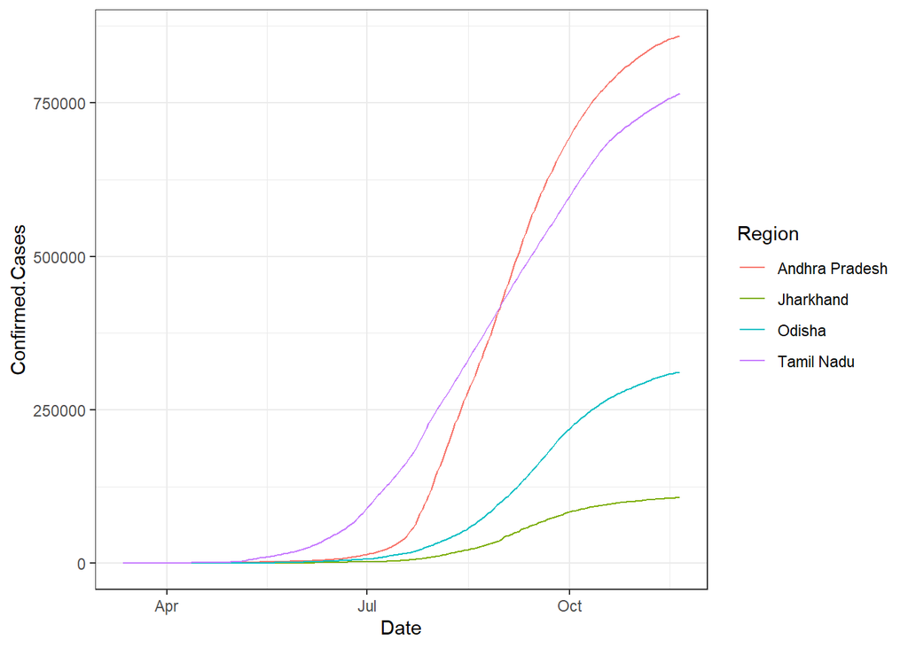

```r
india<-read.csv('covid-india.csv')
india<-delete.na(india,0)
india$Date<-dmy(india$Date)

india_compare<-india %>% filter(Region=='Andhra Pradesh'|Region=='Jharkhand'|Region=='Tamil Nadu'|Region=='Odisha')
india_compare %>% ggplot(aes(x=Date,y=Confirmed.Cases,color=Region))+geom_line()+theme_bw()
```

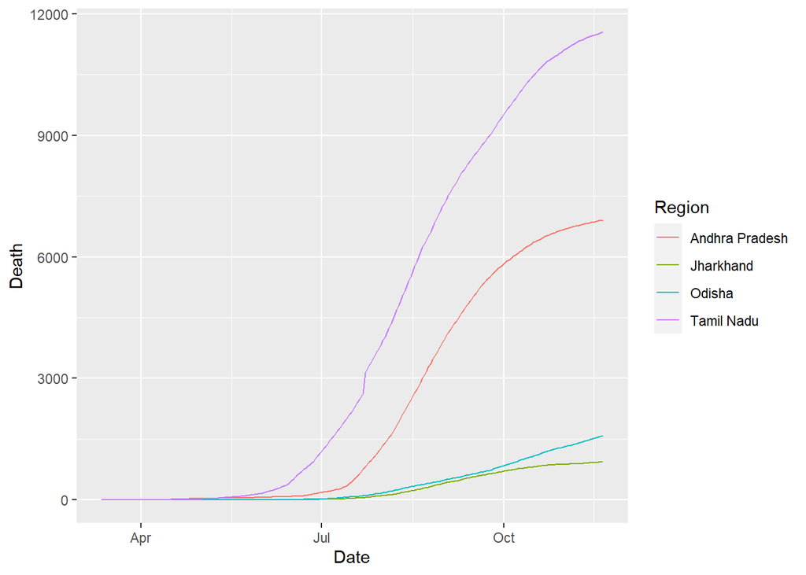

```r
india_compare %>% ggplot(aes(x=Date,y=Death,color=Region))+geom_line()
```

Conclusion: From the comparative study we understand that the number of covid cases and the increase in covid cases in malaria impacted areas is very low as compared to areas where there is low prevalence. This low spread can be due to the higher usage of the drug Hydroxycholoroquine (HCQ) which is used to treat malaria and some auto immune diseases (There is a correlation and causation may or may not be true). A similar pattern was observed between Choloroquine(A stronger but similar drug as HCQ) and SARS(a virus of COVID family).

End of report